# Como identificar o inadimplemente para então buscarmos soluções?

Henrique C Vieira

June 9, 2018

```r
library(dplyr, warn.conflicts = FALSE, verbose = FALSE)
library(readr, warn.conflicts = FALSE, verbose = FALSE)
library(tidyr, warn.conflicts = FALSE, verbose = FALSE)
library(lubridate, warn.conflicts = FALSE, verbose = FALSE)
library(ggplot2)
```

```r
dataset <- read_delim("prosperLoanData_edited.csv", delim = "\t")
# glimpse(dataset)
```

Corrigir o tipo dos dados

```r
# Factor
dataset$CreditGrade <- as.factor(dataset$CreditGrade)
dataset$Term <- as.factor(dataset$Term)
dataset$LoanStatus <- as.factor(dataset$LoanStatus)
dataset$ProsperScore <- as.factor(dataset$ProsperScore)
dataset$BorrowerState <- as.factor(dataset$BorrowerState)
dataset$Occupation <- as.factor(dataset$Occupation)
dataset$EmploymentStatus <- as.factor(dataset$EmploymentStatus)
dataset$IsBorrowerHomeowner <- as.factor(dataset$IsBorrowerHomeowner)
dataset$IncomeRange <- as.factor(dataset$IncomeRange)
dataset$ListingCategory <- as.factor(dataset$ListingCategory)
# glimpse(dataset)
```

Criando as colunas de mês e ano para data de criação do emprestimo e para a data de fechamento do emprestimo

```r
dataset$ListingCreationDate_month <- month(dataset$ListingCreationDate, label = TRUE)
dataset$ListingCreationDate_year <- year(dataset$ListingCreationDate)
dataset$ClosedDate_month <- month(dataset$ClosedDate, label = TRUE)
dataset$ClosedDate_year <- year(dataset$ClosedDate)
```

Reduzindo as opções de situação profissional para quatro.

- Employed
- Not employed
- Other
- NA

```r
dataset$EmploymentStatus4 <- rep(NA, nrow(dataset))
dataset$EmploymentStatus4[dataset$EmploymentStatus == 'Employed'] <- 'Employed'
dataset$EmploymentStatus4[dataset$EmploymentStatus == 'Full-time'] <- 'Employed'
dataset$EmploymentStatus4[dataset$EmploymentStatus == 'Part-time'] <- 'Employed'
dataset$EmploymentStatus4[dataset$EmploymentStatus == 'Self-employed'] <- 'Employed'

dataset$EmploymentStatus4[dataset$EmploymentStatus == 'Not employed'] <- 'Not employed'

dataset$EmploymentStatus4[dataset$EmploymentStatus == 'Other'] <- 'Other'
dataset$EmploymentStatus4[dataset$EmploymentStatus == 'Not available'] <- 'Other'
dataset$EmploymentStatus4[dataset$EmploymentStatus == 'Retired'] <- 'Other'
dataset$EmploymentStatus4 <- as.factor(dataset$EmploymentStatus4)
```

Juntando defaulted com chargedoff

```r
dataset$LoanStatus2 <- dataset$LoanStatus
dataset$LoanStatus2[dataset$LoanStatus2 == 'Chargedoff'] <- 'Defaulted'
```

## slide 1

Temos uma tendência de crescimento no número de empréstimos contabilizados entre 2005 ao primeiro quadrimestre de 2014, então como podemos garantir que estes empréstimos serão quitados?

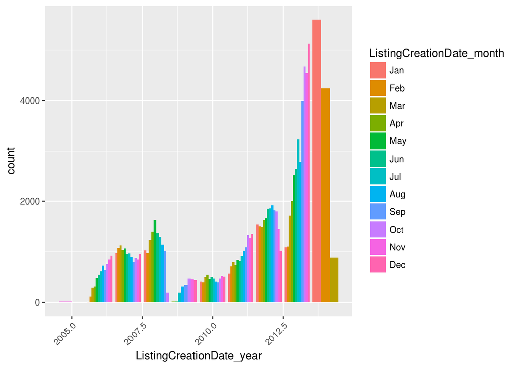

```r
ggplot(dataset, aes(x=ListingCreationDate_year, fill=ListingCreationDate_month)) +
  geom_bar(position = "dodge") +
  theme(axis.text.x = element_text(angle = 45, hjust = 1))
```

## slide 2

Este é o perfils das pessoas que solicitaram o empréstimo entre 2005 a 2014.

### Localidade

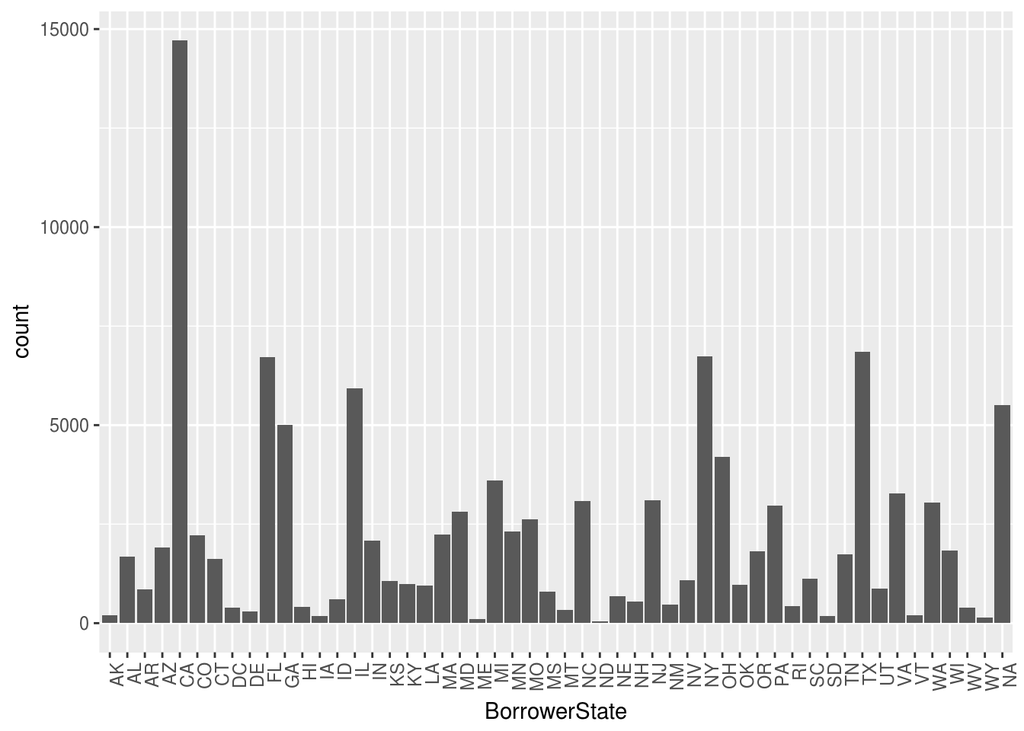

```r
# BorrowerState
# Occupation
# EmploymentStatus
# EmploymentStatusDuration
# IsBorrowerHomeowner
# IncomeRange

ggplot(dataset, aes(x=BorrowerState)) +
  geom_bar() +
  theme(axis.text.x = element_text(angle = 90, hjust = 1))
```

### Ocupação e situação profissional

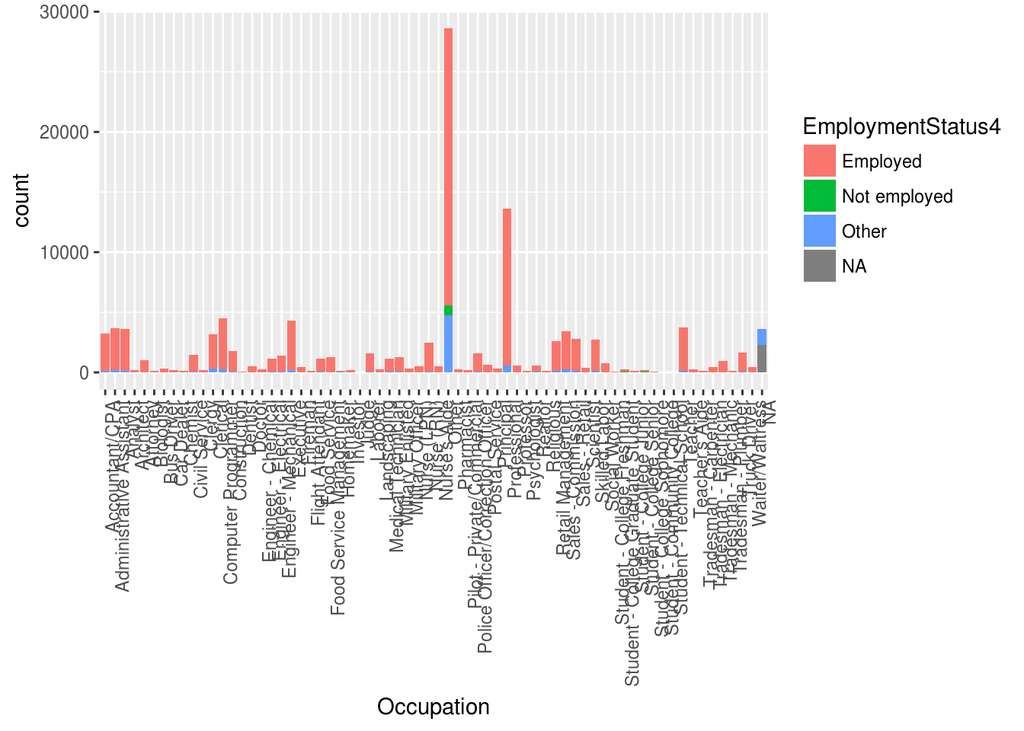

```r
# Occupation
# EmploymentStatus
dataset %>%
  ggplot(aes(x=Occupation, fill=EmploymentStatus4)) +
  geom_bar() +
  theme(axis.text.x = element_text(angle = 90, hjust = 1))
```

### tempo em que está nessa ocupação desde a solicitação do emprestimo

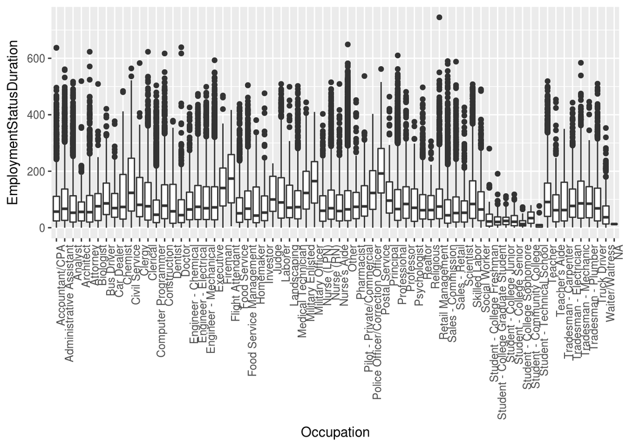

```r
dataset %>%
  filter(EmploymentStatus4 == 'Employed') %>%
  ggplot(aes(x=Occupation, EmploymentStatusDuration)) +
  geom_boxplot() +
  theme(axis.text.x = element_text(angle = 90, hjust = 1))
```

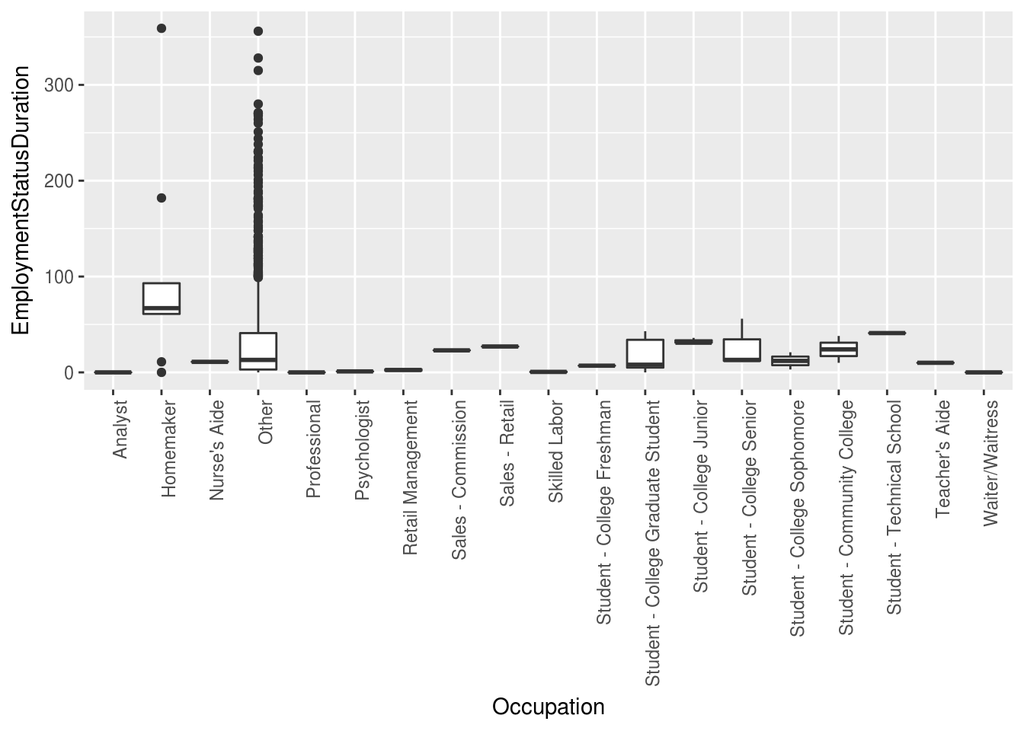

```r
dataset %>%
  filter(EmploymentStatus4 == 'Not employed') %>%
  ggplot(aes(x=Occupation, EmploymentStatusDuration)) +
  geom_boxplot() +
  theme(axis.text.x = element_text(angle = 90, hjust = 1))
```

### Casa própria

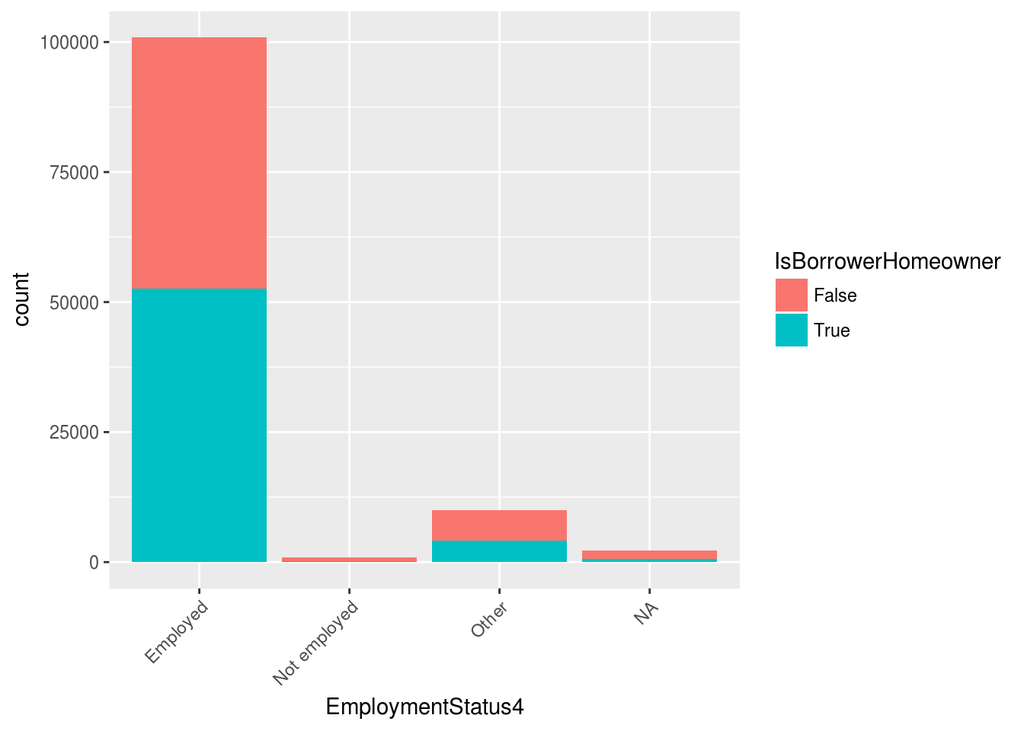

```r
ggplot(dataset, aes(x=EmploymentStatus4, fill=IsBorrowerHomeowner)) +
  geom_bar() +
  theme(axis.text.x = element_text(angle = 45, hjust = 1))
```

### Renda - empregado

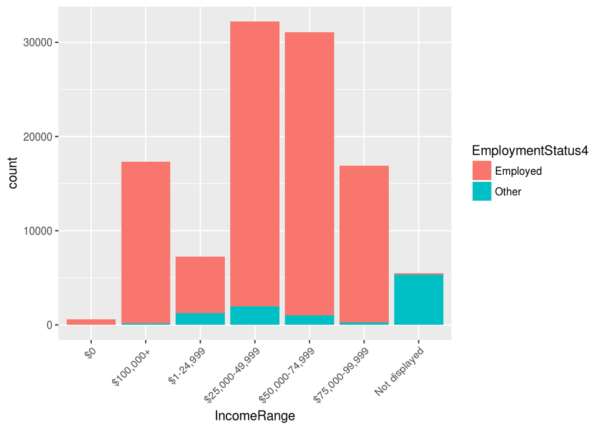

```r
dataset %>%
  filter(EmploymentStatus4 == 'Employed' | EmploymentStatus4 == 'Other') %>%
  ggplot(aes(x=IncomeRange, fill=EmploymentStatus4)) +
  geom_bar() +
  theme(axis.text.x = element_text(angle = 45, hjust = 1))
```

## slide 3

Destas pessoas, quais quitaram e quais se tornaram inadimplentes para atender seus objetivos para o qual solicitaram o empréstimo?

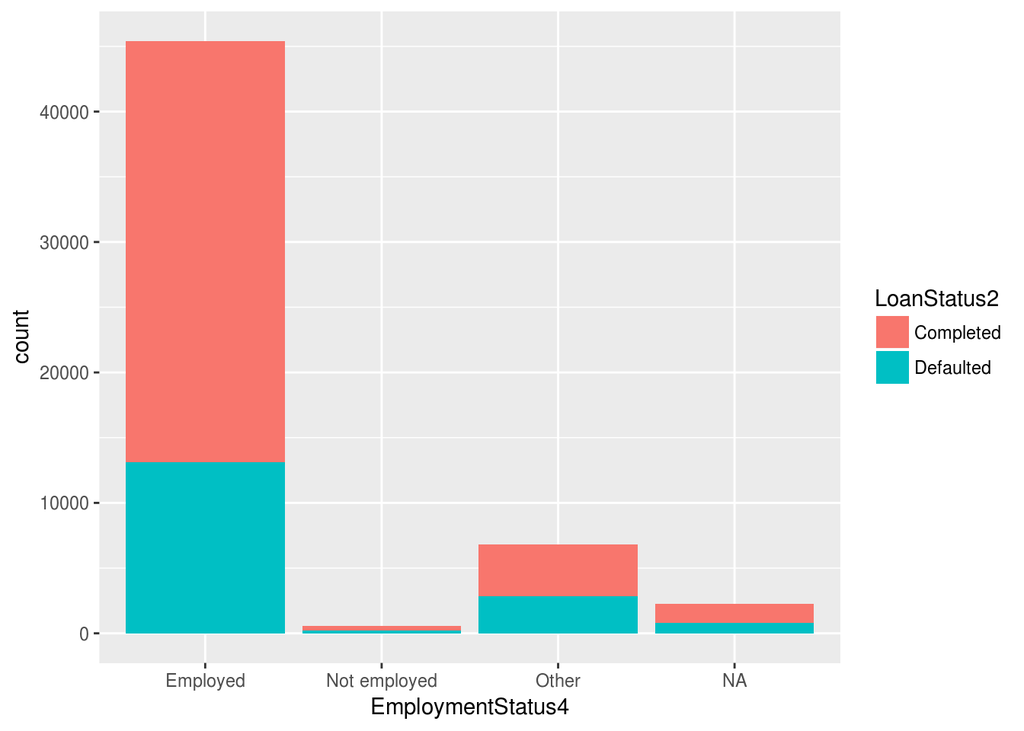

```r
dataset %>%
  filter(LoanStatus2 == 'Completed' | LoanStatus2 == 'Defaulted') %>%
  ggplot(aes(x=EmploymentStatus4, fill=LoanStatus2)) +
  geom_bar()
```

## slide 5

Observado qual o perfil dos inadimplentes, podemos então analisar a sua distribuição. Neste grafico podemos ver que houve uma queda, mas teve uma nova tendência de crescimento da inadimplência.

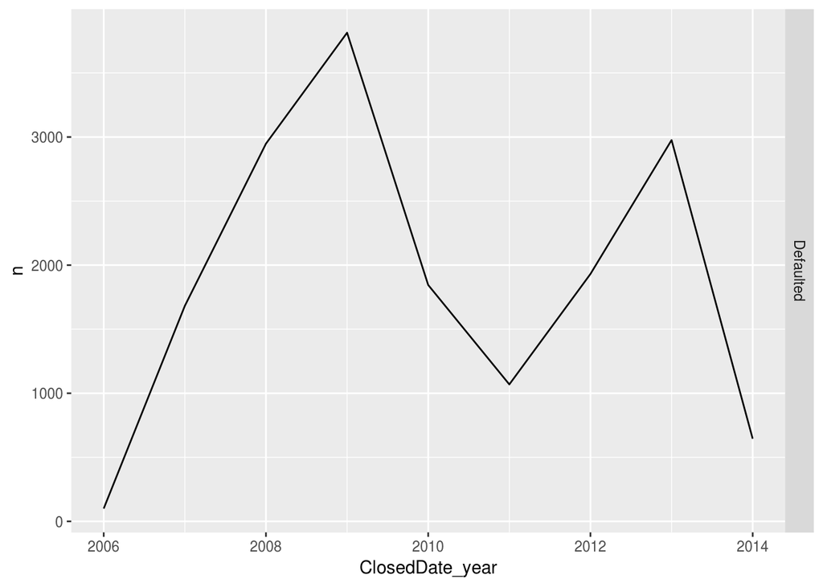

```r
dataset %>%
  filter(LoanStatus2 == 'Defaulted') %>%
  group_by(ClosedDate_year) %>%
  count(LoanStatus2) %>%
  ggplot(aes(x=ClosedDate_year, y=n)) +
  geom_line() +
  facet_grid(LoanStatus2 ~ .)
```

## slide 6

Uma vez que identificamos o perfil e detectamos um crescimento da inadimplência, devemos encontrar incentivos que tornem esses maus clientes em bons clientes. A boa notícia é que vemos abaixo o crescimento no número de bons pagadores, mas podemos melhorar ainda mais.

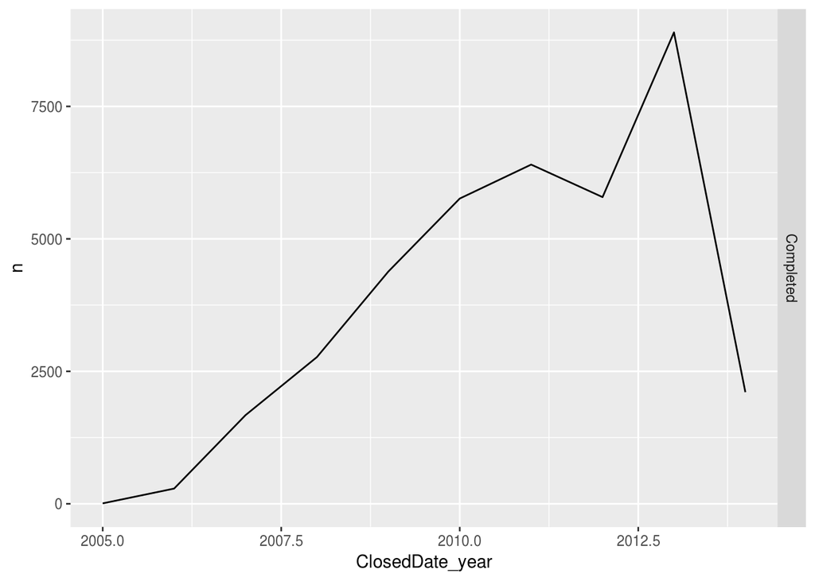

```r
dataset %>%
  filter(LoanStatus2 == 'Completed') %>%
  group_by(ClosedDate_year) %>%
  count(LoanStatus2) %>%
  ggplot(aes(x=ClosedDate_year, y=n)) +
  geom_line() +
  facet_grid(LoanStatus2 ~ .)
```